# Final_Project

Exploring of Soil Test Data for the Fiscle year, 2015

Soil testing provides useful information to help people manage their land. A farmer or home gardener might have his/her soil tested to determine how much lime or fertilizer is needed to grow plants and/or avoid over-applying nutrient sources like manure. Parents might test the soil in their yard to see if hazardous amounts of lead or arsenic are present before installing a backyard playset for their children, or before beginning a new vegetable garden. Archeologists use soil testing to learn about past land use at historical sites. Scientists test soil to monitor the effects of new management practices on soil properties and environmental conditions. The data used for exploratory analysis belongs to soil testing lab, University of Delaware.

Guiding Questions 1. what is the State wide trend of all commercial and homeowner&landscape soil samples submitted in the Fiscle year 2015? 2. what is distribution of samples tested among major crop. 3. Variation in soil PH and nutrients among different Delaware  
counties? 4. What is the soil pH and nutrient trends in different land use classes.

```r
if(! require("pacman")) install.packages("pacman")
pacman::p_load(
  tidyverse,
  here
)
```

```r
library(readxl)
library(tidyverse)
library(here)
```

```r
soil_test_rawdata <- read_excel(here::here("Data", "soil_test_rawdata.xlsx"))
```

Data cleaning:

```r
soil_test_data<-
  soil_test_rawdata %>%
  mutate(type = case_when(
    str_detect(string = type, pattern = "^[L]") ~ "Lawn_Garden",
    str_detect(string = type, pattern = "^[C]") ~ "Commercial_crop",
    str_detect(string = type, pattern = "^[P]") ~ "Professional_Landscaper")) %>%
  select(-"Lab No.",-"FY" , -"zip1" , -"Crop2" ,-"Crop3", -"AEbufph") %>%
  rename("Land_uses" = type,
          "Major_crops" = crop1,
          "Soil_pH" = ph,
          "Organic_matter" = om,
          "P_mgkg" = M3Pmgkg,
          "K_mgkg" = M3Kmgkg,
          "Ca_mgkg" = M3Camgkg,
          "Mg_mgkg" = M3Mgmgkg,
          "Mn_mgkg" = M3Mnmgkg,
          "Zn_mgkg" = M3Znmgkg,
          "Cu_mgkg" = M3Cumgkg,
          "Fe_mgkg" = M3Femgkg,
          "B_mgkg" = M3Bmgkg,
          "Na_mgkg" = M3Namgkg,
          "S_mgkg" = M3Smgkg,
          "Al_mgkg" =  M3Almgkg,
          "Pb_mgkg" = etotpbmgkg) %>%
      arrange(County)
```

```r
soil_test_data<-
  soil_test_data %>%
  rename(Date_received = Received_Date) %>%
  mutate(across(starts_with("Date"), ~ lubridate::mdy(.), .names = "{col}"))
```

```r
soil_test_data<-
  soil_test_data %>%
mutate(Soil_pH = if_else(is.na(Soil_pH), median(Soil_pH, na.rm = T), Soil_pH)) %>%
  mutate(P_mgkg = if_else(is.na(P_mgkg), median(P_mgkg, na.rm = T), P_mgkg)) %>%
mutate(Pb_mgkg = if_else(is.na(Pb_mgkg), median(Pb_mgkg, na.rm = T), Pb_mgkg)) %>%
mutate(Cu_mgkg = if_else(is.na(Cu_mgkg), median(Cu_mgkg, na.rm = T), Cu_mgkg))
```

```r
soil_test_data %>%
summarize(across(everything(), ~ sum(is.na(.))))
```

```
## # A tibble: 1 x 20
##   State County Land_uses Date_received Major_crops Soil_pH Organic_matter P_mgkg
##   <int>  <int>     <int>         <int>       <int>   <int>          <int>  <int>
## 1     0      0         0             0           0       0              0      0
## # ... with 12 more variables: K_mgkg <int>, Ca_mgkg <int>, Mg_mgkg <int>,
## #   Mn_mgkg <int>, Zn_mgkg <int>, Cu_mgkg <int>, Fe_mgkg <int>, B_mgkg <int>,
## #   S_mgkg <int>, Na_mgkg <int>, Al_mgkg <int>, Pb_mgkg <int>
```

```r
sample_over_time<-
  soil_test_data %>%
  group_by(County, Land_uses, Date_received) %>%
  count() %>%
  arrange(Land_uses) %>%
  ungroup() %>%
  ggplot(aes(x = Date_received,
             y = n,
             color = Land_uses))+
  geom_point() +
  facet_wrap(~ County)+
  labs(x = "Date",
       y = " No. of Samples",
       title = "Distribution of soil samples over time for testing")+
  coord_cartesian(ylim = c(0,100))+
  theme_bw()+
  theme(plot.title = element_text(face = "bold"))
```

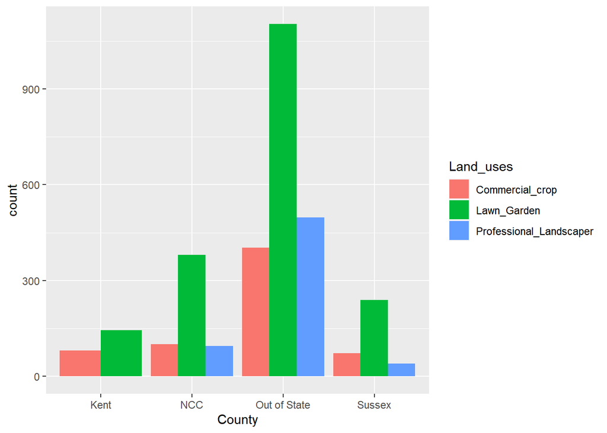

```r
soil_test_data %>%
group_by(Land_uses, County) %>%
  ggplot (aes(x = County,
           fill = Land_uses))+
geom_bar(position = "dodge")
```

Major crops distribution of by county

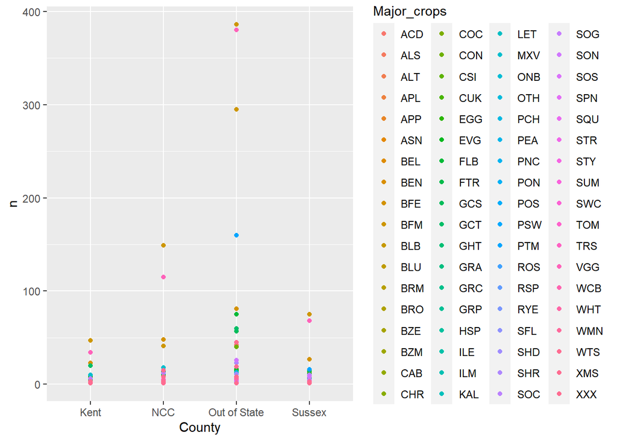

```r
 soil_test_data %>%
  group_by( Major_crops,County) %>%
  count(Land_uses) %>%
 ggplot(aes(x = County,
           y = n,
           color = Major_crops)) +
  geom_point()
```

```r
crop_distribution<-
  soil_test_data %>%
group_by(Major_crops) %>%
  count(sort= TRUE) %>%
  head(20) %>%
   ggplot()+
  geom_col(aes(x=reorder(Major_crops,n),y=n),fill= 'turquoise')+
    coord_flip()+
  labs(
    title = 'Crop Type Distribution',
    x = 'Crop Type',
    y = 'Count'
  )
```

Median values for tested parameters of soil by county and land_use pattern.

```r
soil_test_data %>%
  group_by(County, Land_uses) %>%
  summarize(across(c(where(is.double), -Date_received), ~median(.))) %>%
  ungroup() %>%
arrange(Land_uses)
```

```
## # A tibble: 11 x 17
##    County Land_uses Soil_pH Organic_matter P_mgkg K_mgkg Ca_mgkg Mg_mgkg Mn_mgkg
##    <chr>  <chr>       <dbl>          <dbl>  <dbl>  <dbl>   <dbl>   <dbl>   <dbl>
##  1 Kent   Commerci~     5.7           2.1    68.6   95.0    643.   131.    13.4
##  2 NCC    Commerci~     5.6           3      45.3  131.     885.   167.    50.9
##  3 Out o~ Commerci~     5.8           2.5    69.5   93.2    797.   130.    26.6
##  4 Sussex Commerci~     5.6           1.55  182.    86.0    571.    74.6    9.60
##  5 Kent   Lawn_Gar~     5.9           2.6    73.3  114.     829.   113.    28.6
##  6 NCC    Lawn_Gar~     6.2           5.8    75.3  158.    1610.   230.    35.8
##  7 Out o~ Lawn_Gar~     6.3           4.8    70.1  135.    1639.   207.    37.1
##  8 Sussex Lawn_Gar~     5.8           2.5   116.    74.6    691.   113.    14.2
##  9 NCC    Professi~     5.6           4.4    41.7  136.    1098.   188.    38.6
## 10 Out o~ Professi~     6             4.3    54.2  134.    1433.   210.    20.2
## 11 Sussex Professi~     6.2           4     129.    86.2   1276.   176.    17.2
## # ... with 8 more variables: Zn_mgkg <dbl>, Cu_mgkg <dbl>, Fe_mgkg <dbl>,
## #   B_mgkg <dbl>, S_mgkg <dbl>, Na_mgkg <dbl>, Al_mgkg <dbl>, Pb_mgkg <dbl>
```

```r
pH_classes <- soil_test_data %>%
  mutate(Soil_pH = case_when(
    Soil_pH <= 5.4 ~ "Very low",
    Soil_pH = 5.5 & Soil_pH <= 5.9 ~ "Low",
    Soil_pH = 6.0 & Soil_pH <= 6.4 ~ "Medium",
    Soil_pH = 6.5 & Soil_pH <= 6.9 ~ "High",
    Soil_pH >= 7.0 ~ "Very High"))%>%
      group_by(Soil_pH) %>%
  count(sort= TRUE) %>%
     ggplot()+
  geom_col(aes(x=reorder(Soil_pH,n),y=n),fill= 'orange')+
    coord_flip()+
  labs(
    title = 'Sample distribution in different pH classes',
    x = 'Soil pH classes',
    y = ' Count'
  )
```

```r
PH<-
  soil_test_data %>%
    ggplot(aes(x = Soil_pH)) +
  geom_histogram()+
facet_wrap(~ Land_uses)+
ylab("No. of samples") +
  theme_bw() +
  theme(legend.position="none",
        axis.text = element_text(size=10),
        axis.title = element_text(size=10),
        strip.text = element_text(size=10, face="bold"))
```

```r
 PH_density<-
   soil_test_data %>%
  ggplot( aes(Soil_pH, fill= County)) +
  geom_density(alpha = .5) +
  ggtitle(" Soil pH")
```

```r
OM <-
  soil_test_data %>%
  ggplot( aes(Organic_matter, fill=County)) +
  geom_density(alpha = .5) +
  ggtitle(" Organic matter")
```

```r
soil_nut <-
  soil_test_data %>%
ggplot(aes(x = Soil_pH)) +
  geom_point(aes(y=Ca_mgkg), shape=21, fill="red", color="black", size=2, stroke=.5) +
  geom_point(aes(y=Mg_mgkg), shape=21, fill="blue", color="black", size=2, stroke=.5) +
  geom_point(aes(y=K_mgkg), shape=21, fill="gray", color="black", size=2, stroke=.5)+
  geom_point(aes(y=P_mgkg), shape=21, fill="green", color="black", size=2, stroke=.5)+
   ylab("mg /kg soil") +
  theme_bw() +
  theme(legend.position="none",
        axis.text = element_text(size=14),
        axis.title = element_text(size=16),
        strip.text = element_text(size=16, face="bold"))
```

- Highest number of samples tested are from lawn and garden in all the  
  counties. More lawn and garden sample as compare to commercial crop  
  depicts the increase in urbanization and decrease in farming land in the State.
- Soil pH categories are very helpful to decide the type of crop grown.
- Sussex county samples have high phosphorus content in all land use classes.
- Soil ph directly affect the availability of soil nutrients to the crop.